# Assignment 4

Janice Luong

November 5, 2015

I worked with: Chad Pickering, Rico Lin, Sierra Tevlin, Ricky Safran, Ricky Tran, Fanny Chow, and Hannah Kosinovsky.

Resources: Piazza, STA141 Lecture, Discussion and Office Hours, https://en.wikipedia.org/wiki/Vehicle_identification_number, regex101.com

```r
print(load(url("http://eeyore.ucdavis.edu/stat141/Data/vehicles.rda")))
```

```
## [1] "vposts"
```

```r
body = vposts$body
description = vposts$description
header = vposts$header
```

### Part 1 REGEX

#### 1. Extract the price being asked for the vehicle from the body column, if it is present, and check if it agrees with the actual price in the price column.

```r
#1st capturing group (\\$[[:space:]]*): matches a dollar-sign($) (literally) followed by a space matching for 0 or unlimited times, does it as many times as needed, giving back as needed (greedy)
#2nd capturing group ([0-9+]): first get a single character matching between 0 and 9 and do this 1 to unlimited times. + does this as many times as possible, giving back as needed (greedy)
#3rd capturing group (\\,[0-9]{3})*: match a comma(,) literally. Then match a single character ranging between 0 and 9 and do this exactly 3 times (quantifier {3}). Repeat this entire match 0 to unlimited times, does this as many times as possible, giving back as needed (greedy)
#4th capturing group (\\.[0-9]{2})?: match a period(.) literally. Then match a single character ranging between 0 and 9 and do this exactly twice. Then do the entire thing 0 or 1 times, as many times as possible, giving back as needed (greedy) (take from regex101.com)
#I get 14787 prices
length(grep("(\\$[[:space:]]*)([0-9]+(\\,[0-9]{3})*)(\\.[0-9]{2})?",
            body))
```

```
## [1] 14787
```

```r
#find all possible matches in every post of the body in vposts, gregexpr looks through the body and finds every possible matches
pricesWithNA = gregexpr("(\\$[[:space:]]*)([0-9]+(\\,[0-9]{3})*)(\\.[0-9]{2})?",
                       body)
#now we have 34677 observations
length(pricesWithNA)
```

```
## [1] 34677
```

```r
#There are 3 groupings, dollar sign, prices with the dollar sign, and comma followed by 3 digits
#I took in account cents, even though I did not take that grouping as the price to use because I want to keep it in just incase I decide to go back to use it. This is why I did groupings so that way I can pick and choose what part of the extraction I want to use
getPriceMatches = regmatches(body, pricesWithNA)
#get a sample of getPriceMatches
head(getPriceMatches, 2)
```

```
## [[1]]
## [1] "$29,896"
##
## [[2]]
## [1] "$18,797"
```

```r
#get the largest matched price out of every body in vposts from
getMaxPrice = lapply(getPriceMatches, max)
#change all the prices that start and end with a zerio (0) to NA because a price of 0 dollars is not possible for a vehicle
priceWithNo0 = gsub("^0$", "NA", getMaxPrice)
#get sample of pricesWithNAValues
head(priceWithNo0, 2)
```

```
## [1] "$29,896" "$18,797"
```

```r
#remove anything following a period and replace it with a space, or else it will remove the entire observation
priceNoCents = gsub("\\.[0-9]+", " ", priceWithNo0)
#remove everything that is not a digit and replce it with nothing
priceDigitOnly = gsub("[^0-9]", "", priceNoCents)
#get a sample of priceDigitOnly
head(priceDigitOnly, 2)
```

```
## [1] "29896" "18797"
```

```r
#change noCommaPrices to a numeric class
priceAsNumeric = lapply(priceDigitOnly, as.numeric)

#Change incredibly large values that in assignment 1 were proven to be wrong to NA
findWeirdPrice = as.logical(priceAsNumeric >= 600000)
priceAsNumeric[findWeirdPrice] = NA
maxPricesNoRedic = as.numeric(priceAsNumeric)

#check to see if there are any outlandishly large values
tableOfPrices = table(priceAsNumeric >= 600000)
#returns all FALSE; therefore, I do not have any prices equal or larger than 600000
tableOfPrices
```

```
##
## FALSE
## 14760
```

```r
#go through n amount of rows in vposts (since we do not know how many rows there are in vposts) and if you find the elements that are in vposts$price[x], where x is a row number, compare that to the prices I found using pricesAsNumeric[x], where x is a row number.
priceVSvpostsPrice = sapply(1:nrow(vposts),
                            function(x) vposts$price[x] %in% maxPricesNoRedic[x])

#find my success rate of the prices I found compared to the prices in vposts
successRateOfPrice = sum(priceVSvpostsPrice) / nrow(vposts)
#I have a success rate of ~35.24238
successRateOfPrice
```

```
## [1] 0.3524238
```

I get 14787 prices within the body of vposts, with a success rate (percentage of TRUE) is ~35.24238%.

In my REGEX expression to extract the prices I decided that the dollar sign is not optional because if there isn’t a dollar sign in front of it, it is not a price. I set the restriction so that it must start with a dollar sign because if I did not set these restrictions it would extract numbers that were part of phone numbers, odometer readings or odometer readings that ended with k at the end (for example: 118k odometer, phone numbers at appear as 800 478 2367). At first I was going to change the {1, } (the one after my first [0-9]) to {1,3} but then I realized there are prices such as $4200 which does not have a comma, but is a valid price.

Before I was matching [0-9\.\,] (for example 50.00), but I removed the \. so now I’m matching 50 and then I added (\.[0-9]{2}) which means a period or two numbers are optional. I also removed the \, and added (\,[0-9]{3})* so I can be sure to get values that have 3 digits after a comma so I won’t catch things such as “$300, that is the price”. I also grouped the space, prices without the cents, and prices with the cents. This way I can choose the group that I want, which in this case I want the prices without the cents, while also retaining the data of prices with the cents.

I decided to grab the largest price out of all my matches using lapply(getPriceMatches, max) because there may be a chance that smaller prices are prices for parts of cars.

I decided to group my REGEX so that way I can retain information for later use (such as prices with cents, prices with dollar sign and cents). Grouping allows me to easily choose the grouping I want. This saves me from having to write a complicated REGEX expression to drop the cents when using gsub().

#### 2: Extract a Vehicle Identication Number (VIN) from the body, if it is present. We could use this to both identify details of the car (year it was built, type and model of the car, safety features, body style, engine type, etc.) and also use it to get historical information about the particular car. Add the VIN, if available, to the data frame. How many postings include the VIN?

```r
#set ignore.case = TRUE so it is not case sensitive. This makes A-Za-z unecessary, just a-z
#Vv matches a single character in the list Vv literally (case insensitive), Ii matches a single character in the list Ii literally (case insensitive), Nn matches a single character in the list Nn literally (case insensitive) #[[:space:][:punct:]]* match a single character present in the list below, * maches between zero and unlimited times, as many times as possible, giving back as needed (greedy), [:space:] matches white space characters, [:punct:] matches punctuation characters
#[0-9a-hj-np-z]{11,17}: 0-9 matches a single character in the range between 0 and 9, a-h matches a single character in the range between a and h (case insensitive), j-n matches a single character in the range between j and n (case insensitive), p-z matches a single character in the range between p and z (case insensitive), {11,17} matches between 11 and 17 times, as many times as possible, giving back as needed (greedy)
#I get 7631 matches
length(grep("[Vv][Ii][Nn][[:space:][:punct:]]*[a-z]*[[:space:][:punct:]]*([0-9a-hj-np-z]{11,17})",
            body,
            ignore.case = TRUE))
```

```
## [1] 7631
```

```r
#find matches within the body of vposts
VINWithNA = regexec("[Vv][Ii][Nn][[:space:][:punct:]]*[a-z]*[[:space:][:punct:]]*([0-9a-hj-np-z]{11,17})",
                    body,
                    ignore.case = TRUE)

#get all the matches/groupings found per body post in vposts
getVINMatches = regmatches(body, VINWithNA)
#get a sample of getVINMatches, this shows me all my matches/groupings
head(getVINMatches, 2)
```

```
## [[1]]
## [1] "VIN: 2G1FT1EW1C9106920" "2G1FT1EW1C9106920"
##
## [[2]]
## [1] "VIN: 2GNFLNEK7D6324351" "2GNFLNEK7D6324351"
```

```r
#get the 2nd grouping of getVINMatches, which is ([0-9a-hj-np-z]{11,17}), where it is just the VIN number without the word VIN (case insensitive), any words or any punctuation
VIN1stGroup = sapply(getVINMatches, function(a) a[2])
#get a sample of VIN
head(VIN1stGroup, 2)
```

```
## [1] "2G1FT1EW1C9106920" "2GNFLNEK7D6324351"
```

```r
#make a new column in vposts called VIN and assign it to VIN
vposts$VIN = VIN1stGroup
#get a sample of vposts$VIN
head(vposts$VIN, 2)
```

```
## [1] "2G1FT1EW1C9106920" "2GNFLNEK7D6324351"
```

I get 7631 matches for VIN within the body of vposts.

For my REGEX for VIN, at first I had ([Vv][Ii][Nn])?[[:punct:][:space:]]* in front of [0-9A-HJ-NP-Z]{11,17}; but sometimes there are words between the word VIN and the VIN number. For example, some people may write “Vin Number: 2FMDK4KC5DBC55012”. So I cannot always be sure that following the word VIN and a space/punctuation is the VIN number. When I allowed my expression to only match [0-9A-HJ-NP-Z]{11,17}, it started matching words such as “Aftermarket”, “Supercharged” and “representat”. I decided to change my regex code so it has match the letters [Vv][Ii][Nn]. I decided to change my regex code so it has match the letters [Vv][Ii][Nn]. Since not all VIN were 17 characters long, {11,17} ensures that my REGEX expression will match a minimum of 11 characters and match a maximum of 17 characters (taken from Wikipedia).

VIN cannot contain I (i), O (o), or Q (q) to avoid confusions with the digits 0 or 1 (taken from Wikipedia). Setting restrictions on which letters are allowed to be in VIN helps to ensure that I am not taking some random word that just also happens to be 11 to 17 characters long. Although VIN can only consist of capital letters, I allowed for lower-case letters incase someone makes a typo and forgets to capitalize their VIN’s.

#### 3: Extract phone numbers from the body column, and again add these as a new column. How many posts include a phone number?

```r
#1st capturing group ([[:space:][:punct:]]?([0-9]|zero|one|two|three|four|five|six|seven|eight|nine)){3}: [:space:] matches white space characters, [:punct:] matches punctuation characters, ? matches between zero and one time, as many times as possible, giving back as needed (greedy)
#3rd capturing group ([[:space:][:punct:]]?([0-9]|zero|one|two|three|four|five|six|seven|eight|nine)){7}: [:space:] matches white space characters, [:punct:] matches punctuation characters, ? matches between zero and one time, as many times as possible, giving back as needed (greedy), ? matches between zero and one time, as many times as possible, giving back as needed [greedy]
  #4th capturing group ([0-9]|zero|one|two|three|four|five|six|seven|eight|nine): 0-9 matches a digit, zero matches the characters zero literally (case insensitive) and so on for up to nine.
#finally, {7} matches exactly 7 times (take from regex101.com)
#when using ignore.case = TRUE i get 17725 results
length(grep("\\(?([[:space:][:punct:]]?([0-9]|zero|one|two|three|four|five|six|seven|eight|nine)){3}\\)?([[:space:][:punct:]]?([0-9]|zero|one|two|three|four|five|six|seven|eight|nine)){7}",
            body,
            ignore.case = TRUE))
```

```
## [1] 17725
```

```r
#find matches within the body of vposts
phoneNumberWithNA = regexec("\\(?([[:space:][:punct:]]?([0-9]|zero|one|two|three|four|five|six|seven|eight|nine)){3}\\)?([[:space:][:punct:]]?([0-9]|zero|one|two|three|four|five|six|seven|eight|nine)){7}",
                            body,
                            ignore.case = TRUE)
#add NA's so now I have 34677 observations
length(phoneNumberWithNA)
```

```
## [1] 34677
```

```r
getPhoneNumberMatches = regmatches(body, phoneNumberWithNA)
#get a sample of getPhoneNumberMatches
head(getPhoneNumberMatches, 2)
```

```
## [[1]]
## [1] "(508) 205-1046" "8"              "8"              "6"
## [5] "6"
##
## [[2]]
## [1] "(508) 205-1046" "8"              "8"              "6"
## [5] "6"
```

```r
#get the first grouping/match of getPhoneNumberMatches
phoneNumber1st = sapply(getPhoneNumberMatches, function(b) b[1])
#get a head of phoneNumber
#many of the phone numbers are repeated
head(phoneNumber1st, 2)
```

```
## [1] "(508) 205-1046" "(508) 205-1046"
```

```r
#remove white spaces or new lines (\n) in the front and end of our matches
trimPhoneNumber = trimws(phoneNumber1st)
#remove anything that is not a digit or words: zero, one, two, three, four, five, six, seven, eight, nine, or a space
phoneNumbers= gsub("[^0-9|zero|one|two|three|four|five|six|seven|eight|nine ]", "", trimPhoneNumber)
head(phoneNumbers, 2)
```

```
## [1] "508 2051046" "508 2051046"
```

```r
#make a new column in vposts called phoneNumber
vposts$phoneNumber = phoneNumbers
```

```r
#remove everything that is not a digit, space or zero, one, two three, four, five, six, seven, eight, nine
phoneNumber = gsub("[^0-9|zero|one|two|three|four|five|six|seven|eight|nine| ]", "", phoneNumber1st)

#make a new column in vposts called phoneNumber
vposts$phoneNumber = phoneNumber
#sample of vposts$phoneNumber
head(vposts$phoneNumber, 2)
```

```
## [1] "508 2051046" "508 2051046"
```

I get 17725 matches for phone numbers within the body of vposts.

At first I originally I had written \(?[0-9]{3}\)?[[:space:][:punct:]]*[0-9]{3}[[:space:][:punct:]]* [0-9]{4} to extract phone numbers (ignore the space right after the second *). Then I took a look at my matches, I noticed the body’s that were missing phone numbers did have phone numbers to contact the seller of the vehicle; however, they would write part of the phone number out in written words. For example (508) 45 eight - seven455 ot (five six2) 333 nine two 14. I wanted to make sure I picked up most phone numbers even if this means picking up weird matches. Then I wrote \(?([[:space:][:punct:]]?([0-9]|zero|one|two|three|four|five|six|seven|eight|nine)){3}\)?([[:space:][:punct:]]?([0-9]|zero|one|two|three|four|five|six|seven|eight|nine)){7}, but it started picking up or spaces in front of the first digit of the phone number and I did not want that since I planned on removing anything that was not a number via gsub() before placing it into vposts as a new column.

So I changed it to this \(?(([0-9]|zero|one|two|three|four|five|six|seven|eight|nine)){3}\)?([[:space:][:punct:]]?([0-9]|zero|one|two|three|four|five|six|seven|eight|nine)){7}, but this caused me to have less matches because some phone numbers were written as ( 509 ) for the area code, so I changed back to the one I had before. I also later realized I only wanted to remove anything that was not a digit, digits written in words or a space because removing the spaces would make the written out numbers hard to see/read, for example, fivesix2333ninetwo14 is much harder to see/read compared to five six2 333 nine two 14

There are some issues with my REGEX expression where it grabs phone numbers. I noticed that sometimes it will grab numbers that are not phone numbers, but matches that happen to be the same length as phone numbers (10 digits, with or without spaces between them) so this is the trade off that I am willing to accept.

I noticed that when I took a sample (via head()) of the phoneNumbers1st, many of the phone numbers are repeats. I realized that the body of vposts has many repeated posting of the same vehicle. This means that although I matched 17725 phone numbers, I actually have less than 17725 unique phone numbers matched.

#### 4. Extract email addresses from the body column, and again add these as a new column. How many posts include an email address?

```r
#there are 107 emails
length(grep("[a-z0-9\\.\\_\\-]+\\@[a-z0-9\\_\\-]+\\.[a-z0-9]{2,}",
            body,
            ignore.case = TRUE))
```

```
## [1] 107
```

```r
#[a-z0-9] matches a digit or letter
#[a-z0-9\.\_\-]*: matches a digit or letter, \\. matches . literally, \\_ matches _ literally, \\- matches - literally, \\@ matches @ literally, * repeats between zero and unlimited times, as many times as possible, giving back as needed (greedy)
#[a-z0-9\_\-]+:matches a digit or letter, \\_ matches _ literally, \\- matches - literally, \\. matches . literally, + repeats between 1 and unlimited times, as many times as possible, giving back as needed (greedy)
#[a-z0-9]{2,}: matches a digit or letter, {2,} repeats between 2 and unlimited times, as many times as possible, giving back as needed (greedy) (take from regex101.com)
#find matches within the body of vposts
emailsWithNA = regexec("[a-z0-9\\.\\_\\-]+\\@[a-z0-9\\_\\-]+\\.[a-z0-9]{2,}",
                       body,
                       ignore.case = TRUE)
```

```r
#gets all the groupings, instances, or matches found
emailsMatches = regmatches(body, emailsWithNA)

#grab the first and only instance of emailsMatches
emails = sapply(emailsMatches, function(b) b[1])

#make emails a column inside vposts called email
vposts$email = emails

#find website matches within the body of vposts. see below for description of code
#1st capturing group ((https?:\\/\\/)?([0-9a-z\\-\\/]+\\.)+(com|org|net|edu)([[:punct:]a-z0-9]+[^\\.[:space:]])?):
  #2nd capturing group (https?:\\/\\/)?: matches http with an optional s, matches : and // then repeat this entire grouping between 0 or 1 times, as many times as possible, giving back as needed (greedy)
  #3rd capturing group is ([0-9a-z\\-\\/]+\.)+
  #4th capturing group is (com|org|net|edu)
  #5th capturing group is ([[:punct:]a-z0-9]+[^\\.[:space:]])?
length(grep("[^\\@a-z]((https?:\\/\\/)?([0-9a-z\\-\\/]+\\.)+(com|org|net|edu|gov)([[:punct:]a-z0-9]+[^\\.[:space:]])?)",
            body,
            ignore.case = TRUE))
```

```
## [1] 13915
```

```r
#find matches within the body of vposts
websiteWithNA = regexec("[^\\@a-z]((https?:\\/\\/)?([0-9a-z\\-\\/]+\\.)+(com|org|net|edu|gov)([[:punct:]a-z0-9]+[^\\.[:space:]])?)",
                        body,
                        ignore.case = TRUE)

#find all matches in body for websites
getMatchesWebsite = regmatches(body, websiteWithNA)
#get a sample of getMatchesWebsite
head(getMatchesWebsite, 2)
```

```
## [[1]]
## [1] " automaxpreowned.com/Address:" "automaxpreowned.com/Address:"
## [3] ""                              "automaxpreowned."
## [5] "com"                           "/Address:"
##
## [[2]]
## [1] " automaxpreowned.com/Address:" "automaxpreowned.com/Address:"
## [3] ""                              "automaxpreowned."
## [5] "com"                           "/Address:"
```

```r
#get the first grouping/match for websites
website1stInstance = sapply(getMatchesWebsite, function(a) a[1])
#get a sample of website1stInstance
head(website1stInstance, 2)
```

```
## [1] " automaxpreowned.com/Address:" " automaxpreowned.com/Address:"
```

```r
#removes spaces in front and back of the website links, including new line (\n)
trimWebsite = trimws(website1stInstance)
#[^\\/\\.] negative look ahead, look for anything that is not a slash or a period
#replace anything that is in front of www. (including www.) with just www.
websiteRemoveNum = gsub("[^\\/\\.]+www\\.","www.", trimWebsite)
#remove anything that is a : or a - that are in front of the matches and replace it with nothing
website = gsub("\\:|\\-", "", websiteRemoveNum)

vposts$website = website

#get a sample of vposts$website
#many websites are repeated because people would put their website multiple times in their body of their post
head(vposts$website, 2)
```

```
## [1] "automaxpreowned.com/Address" "automaxpreowned.com/Address"
```

With my REGEX code for emails, I got 107 matches within the body of vposts.

After I extracted the emails, I noticed that there was very little emails, and since many of the vehicle postings in my data set were repeats, some of the emails were likely repeats. So this meant I actually have less than 107 unique emails. Originally I had [a-z0-9\.\_\-] * (ignore space after *), but then it started grabbing things such as @60.00 or @mytruckcity.com as emails by chaing the* to a + which leads to [a-z0-9\.\_\-] * (ignore space after *). So I set my emails so that it must start with a letter, digit, literal ., literal -, literal _ or else it will start grabbing Then my REGEX expression will look for letters, digits, dash, underscore, or periods and it repeats this 1 or unlimited times until it hits a at(@) sign. Although : is a valid punctuation for emails, it is extremely rare for emails to have them so I did not add it as part of my REGEX, I also noticed I get much nicer looking results when I leave it out (take from Piazza). Then REGEX looks for literal period. Then it is followed by a minimum of two characters because the shortest domain is two characters such as .bz or .cn

I do get errors, such s etc…mllcdk@gmail.com as an email. It is a vaild email since we are allowed to have periods in our emails, however, I am confident that etc… is not part of the original email address. Since many of the posts in the body of vposts were repeats, it is likely that I have some repeated emails; therefore, I actually have less than 107 unique emails.

I decided to also look for websites because I found very little emails, and websites are also a good way to find vehicle postings and possible contact information. With my REGEX code for websites, I got 13915 matches.

In my REGEX expression above for extracting websites from the body of vposts, first I match the www. (not case sensitive) by doing [0-9a-z\-]+ . The first character w matches with [0-9a-z\-] and then + says to repeat it for the second character w and then the next character match, which is a w.

The next character is period (.); however, it does not match [0-9a-z-] since there is no \. Now that w is repeeated three times (which falls in +, REGEX moves on and it matches the next thing, which is a period (.), ([0-9a-z\-] |We’re here| \.)+ .

We have finally matched www. with our REGEX. Now the next part, for example getting the ‘a’ from www.abc.com, it repeats and tries to repeat the entire over and will succeed.

I can explain this similarly with a1b2b3, which can be extracted from the REGEX expression [a-z][0-9][a-z][0-9][a-z][0-9] because it goes: character, number, character, number, character, number. But if we wanted something such as abc1abcd2ab3, we need to make the character length vary. We can do {1, 1000000}, but that is too cumbersome to write so we do +, which does from 1 to infinity. Now we have [a-z]+[0-9][a-z]+[0-9][a-z]+[0-9]. Now let’s replace the numbers with periods and we get [a-z]+\.[a-z]+\.[a-z]+\. What we have is good so far, except it only works when the letters are followed by a period that is repeated 3 times, so what if it only happens once? Or 100 times?

I can easily solve this by grouping (wrapping it in parenthesis) it up into a single instance ([a-z]+\.) and then we repeat this instance 1 to unlimited times ([a-z]+\.)+

Now this will work for abc.abcd.ab. Now add numbers: ([a-z0-9]+\.)+ Now add dash: [a-z0-9-]+\.)+ Now we have what we need to find www.sdgfdsfg.

Then it will try it with com. But since com doesn’t end in a period, it stops there and analyzes with (com|org|net|edu|gov). Using the parameter ignore.case allows for me to pick up weird things such as .Com, Http, .EDu, etc (taken from Piazza).

Next REGEX will find anything after the com|org|net|edu|gov with a puncuation ( @ #), letters or numbers, but it won’t end the website with a space or a period because website links after the com|org|net|edu|gov cannot have periods or space in them.

The REGEX expression I used to find websites has an issue. I noticed that it takes the domain from emails as a website. For examples sdfjioe@yahoo.com or oijdfie@gmail.com. REGEX would take yahoo.com and gmail.com as websites. Although yahoo.com and gmail.com are vaild websites, it is unlikely that I will find a car posting there. So I added the expression [^\\@] in front of my website REGEX expression so that way it will not match the literal at(@) sign, since all email domains are preceeded by an at(@) sign. But it was still matching email domains as websites. I noticed that it would continue to grab the first instance of a letter after the at(@) sign so I added [^a-z] so it would not grab the first instance of a letter after the at(@) sign, resulting in [^\\@a-z]. This ensures that my REGEX will not match email domains as a website.

I then trimmed the website matches I found of white spaces or new lines () using the function trimws(). Afterwards I used gsub() to remove anything that was not a or a period in front of www. with just www. because I noticed that in my matches, there were digits in front of my websites that started with www., such as 4093www.abc.com. With gsub(), I didn’t have to change my REGEX to accomate for this and then loose matches. Instead, I can just drop/remove anything I don’t want without having to miss any matches.

#### 5. Find the year in the description or body and compare it with the value in the year column.

```r
#1st capturing group (19[0-9]{2}|20[0-1][0-9]): 19 matches the characters 19 literally, {2} matches exactly 2 times, 0-9 a single character in the range between 0 and 9 OR 20 matches the characters 20 literally, 0-1 a single character in the range between 0 and 1, 0-9 a single character in the range between 0 and 9
#[^0-9A-Za-z] match a single character not present in the list (inside brackets): 0-9 a single character in the range between 0 and 9, a-z a single character in the range between a and z (case insensitive) (take from regex101.com)
#I found 28811 years
length(grep("(19[0-9]{2}|20[0-1][0-9])[^0-9a-z]",
            description,
            ignore.case = TRUE))
```

```
## [1] 28811
```

```r
#The first value is the whole match, then each value after that is what's in parenthesis. So result[0] would be 1990\n, result[1] would be 1990. This is why I want the second column of year1 because it has the value of what is in the paraenthesis when I do sapply(getMatchInfoYear, function(a) a[2])
#get it from description because it is shorter than body so less likely to grab other numbers that just happen to be 4 digits long that match the REGEX below
#find matches within the description of vposts
yearWithNA = regexec("(19[0-9]{2}|20[0-1][0-7])[^0-9a-z]",
                     description,
                     ignore.case = TRUE)

#find all the matches corresponding to my REGEX expression
getYearMatches = regmatches(description, yearWithNA)
#get sample of getYearMatches
head(getYearMatches, 2)
```

```
## [[1]]
## [1] "2012 " "2012"
##
## [[2]]
## [1] "2013 " "2013"
```

```r
#take the second grouping of getMatchInfoYear to get the one without the space in front of the year
year2NDGroup = sapply(getYearMatches, function(a) a[2])

#make a column of the years I found
vposts$myYear = year2NDGroup
#get a sample of vposts$myYear
head(vposts$myYear, 2)
```

```
## [1] "2012" "2013"
```

```r
tableOfYears = table(vposts$year == vposts$myYear)
#success rate of ~98.4431%
successRateOfYears = tableOfYears[[2]] / (tableOfYears[[1]] + tableOfYears[[2]])
successRateOfYears
```

```
## [1] 0.984431
```

I get 28811 matches for years within the description from vposts, with a success rate (percentage of TRUE) of ~98.4431%.

I used the description of vposts to find the years because it has less information in it. This helps ensures that I am not taking some weird number that happen to match my REGEX expression for years. The description has the year of the vehicles.

The acutal year is grouped, which means the first result is year. REGEX just groups it, so it does not change my match. SO REGEX will first find the entire thing that I am looking for, then REGEX finds the actual value I am looking for, which is in paraenthesis. It is similar to looking for your house, you look for homes around it or other streets, but your main goal is to find your home.

#### 6. Determine the model of the car, e.g., S60, Boxter, Cayman, 911, Jetta. This includes correcting mis-spelled or abbreviated model names.

```r
#splitting each word in the header based on the spacing
splitHeader = sapply(vposts$header, function(x) strsplit(x," "))

#find the pattern, which is vposts$maker and then find this pattern in splitHeader with an error of 1 (max.distance). This means that there can only be 1 error (change in letter, missing a letter, extra letter), and it is not case sensitive
findPatternMatch = lapply(1:nrow(vposts),
                    function(x) agrep(vposts$maker[x], splitHeader[[x]], max.distance = 1, ignore.case=TRUE))

#if the length of findPatternMatch is not 0, then we add 1 to the index so we can get the next index, which is the model, because in general the maker follows the model, if it is 0 then set it to NA because it is not a maker
model = tolower(lapply(1:nrow(vposts),
                       function(x) if (length(findPatternMatch[[x]]) != 0) splitHeader[[x]][min(findPatternMatch[[x]]) + 1] else return(NA)))

#make a new column in vposts called model and assign it to model
vposts$model = model

#make models into a vector using model and then do a count of each model and sort it from highest to lowest count, then take a sample of the first 20
head(sort(table(unlist(model)), decreasing = TRUE), 20)
```

```
##
##        na     civic    accord     grand     camry    altima   corolla
##      2546       854       842       785       754       665       537
##   mustang    maxima       ram            explorer     focus     jetta
##       431       384       383       360       305       300       281
## silverado     prius    sonata    escape    sienna  wrangler
##       256       253       252       248       246       233
```

I used the column maker within vposts to as my pattern and I compared it to header to find number of each model in the data set. When I find matches, I used agrep(), where my pattern was all the makers, and look for this pattern in the header (splitHeader) with an error of 1. An error of 1 means that it there can only be a misspelling of 1 letter, missing 1 letter, or 1 extra letter in the spelling of the maker in order for it to be counted as a match.

After finding all the matches of the makers, if findPatternMatch is not at index 0, then add 1 to it, so we can get the next index because the model generally follows after the maker, so the model of the vehicle would be in the index to the right of the maker. If the maker is at index 0, then set it to NA because this means it is not a maker or it was misspelled by more than a distance of 1.

### Part 2 Modeling

```r
#change year 2022 to year 2002
getYear2022 = which(vposts$year == "2022")
vposts[getYear2022, "year"] = 2002

#subtract from 2017 because that is the newest model possible for vehicles currently in 2015
vposts$age_of_vehicle = 2016 - vposts$year

#makes a new column called ageOfVehicle in vposts
#combines pre-existing or create a new category into a new factor called any name of choice
comboCondition = (vposts$condition)

#combine all these conditions into the pre-existing conditions called used
used = c("pre owned",  "preowned",
         "pre-owned", "preownes")

#combine all these conditions into the pre-existing condition called salvage
salvage = c("needs restoration!", "not running",
            "restoration project", "project car",
            "needs restored", "project",
            "rebuildable project", "needs work",
            "restore", "project",
            "needs bodywork", "needs work/for parts",
            "needs total restore")

#combine all these conditions into the pre-existing fair called fair
fair = c("restoration", "restored",
         "nice rolling restoration")

#combine all these conditions into a new condition called like_new
like_new = c("very good", "like new")

#combine all these conditions into the pre-existing condition called other
other = c("0used", "carfax guarantee!!",
          "207,400", "certified",
          "ac/heater", "honnda",
          "parts", "nice teuck",
          "rough but runs", "front side damage",
          "hit and run :( gently", "mint",
          "nice", "complete parts car, blown engine",
          "muscle car restore", "superb original")
```

```r
comboCondition = as.character(vposts$condition)

tmp_used = comboCondition %in% used #create temp variable
#name the category (can be a new category or pre-existing)
comboCondition[tmp_used] = "used"
tmp_salvage = comboCondition %in% salvage
comboCondition[tmp_salvage] = "salvage"
tmp_fair = comboCondition %in% fair
comboCondition[tmp_fair] = "fair"
tmp_like_new = comboCondition %in% like_new
comboCondition[tmp_like_new] = "like new"
tmp_other = comboCondition %in% other
comboCondition[tmp_other] = "other"
#turn back into a factor/level in conditions
vposts$updated_Condition = factor(comboCondition)

levels(vposts$updated_Condition)
```

```
## [1] "excellent" "fair"      "good"      "like new"  "new"       "other"
## [7] "salvage"   "used"
```

```r
vposts$updated_Condition = factor(vposts$updated_Condition, levels = c("other", "salvage", "fair", "used", "good", "like_new", "excellent", "new"), ordered = TRUE)
```

I noticed that one of the vehicle’s year was 2022, which cannot be possible because it is currently 2015, so the latest model of a car can only be 2016. This was likely a typo, so I changed it to year 2002.

```r
library(ggplot2)

altima = vposts[which(vposts$model == "altima"),]
```

```r
#plot price vs odometer by city for Nissian Altima
plotAltima = ggplot(altima, aes(odometer, price, col = age_of_vehicle))+geom_point(aes(size = updated_Condition))+
  labs(x = "Odometer Reading (miles)", y = "Price (dollars)",
       title = "1. Maker: Nissian, Model: Altima")+
  theme(plot.title = element_text(size = 24, face = "bold", vjust = 2),
        panel.grid.major = element_line(colour = "black", size = .5),
        axis.text.x = element_text(angle = 90, hjust = 1))+
  scale_color_gradientn(colours = c("blue4", "red", "orange", "aquamarine4"))+
  scale_x_continuous(limits = c(0, 300000))+
  scale_y_continuous(limits = c(0, 20000), breaks = seq(0, 20000, 5000))+
  facet_wrap(~city, nrow = 2, ncol = 4)

#plot price vs odometer for Nissian Altima
plotAltima2 = ggplot(altima, aes(odometer, price, col = age_of_vehicle))+geom_point(aes(size = updated_Condition))+
  labs(x = "Odometer Reading (miles)", y = "Price (dollars)",
       title = "2. Maker: Nissian, Model: Altiam")+
  theme(plot.title = element_text(size = 15, face = "bold", vjust = 2),
        panel.grid.major = element_line(colour = "black", size = .5),
        panel.background = element_rect(fill = 'white'))+
  scale_x_continuous(limits = c(0, 1e+05))+
  scale_y_continuous(limits = c(0, 20000))+
  scale_color_gradient(low="coral", high="coral4")
```

```r
prius = vposts[which(vposts$model == "prius"),]

#plot price vs odometer by city for Toyota Prius
plotPrius = ggplot(prius, aes(odometer, price, col = age_of_vehicle))+geom_point(aes(size = updated_Condition))+
  labs(x = "Odometer Reading (miles)", y = "Price (dollars)",
       title = "1. Maker: Toyota, Model: Prius")+
  theme(plot.title = element_text(size = 24, face = "bold", vjust = 2),
        panel.grid.major = element_line(colour = "black", size = .5),
        axis.text.x = element_text(angle = 90, hjust = 1))+
  scale_color_gradientn(colours = c("green", "cyan1", "chocolate4", "blueviolet"))+
  scale_x_continuous(limits = c(0, 300000))+
  scale_y_continuous(limits = c(0, 30000), breaks = seq(0, 30000, 5000))+
  facet_wrap(~city, nrow = 2, ncol = 4)

#plot price vs odometer for Toyota Prius
plotPrius2 = ggplot(prius, aes(odometer, price, col = age_of_vehicle))+geom_point(aes(size = updated_Condition))+
  labs(x = "Odometer Reading (miles)", y = "Price (dollars)",
       title = "2. Maker: Toyota, Model: Prius")+
  theme(plot.title = element_text(size = 15, face = "bold", vjust = 2),
        panel.grid.major = element_line(colour = "black", size = .5),
        panel.background = element_rect(fill = 'white'))+
  scale_x_continuous(limits = c(0, 250000))+
  scale_y_continuous(limits = c(0, 30000))+
  scale_color_gradient(low="darkslategray1", high="darkslategray4")
```

```r
#fit the vehicle in a linear model. Price of Altima is regressed on age, odometer and condition
altimaModel = lm(price ~ age_of_vehicle + odometer + updated_Condition, data = altima)
```

```r
##R^2 is 0.5831 (listed as mutiple R-squared)
summary(altimaModel)
```

[output not shown]

```r
predictAltima = data.frame(age_of_vehicle = c(1, 3, 5, 8, 11, 15, 24),
                              odometer = c(31, 100, 1961, 4966, 10854, 100000, 206000),
                              updated_Condition = c("new", "excellent", "good", "used", "fair", "salvage", "other"))
pricePredictAltima = predict(altimaModel, predictAltima)
pricePredictAltima
```

```
##           1           2           3           4           5           6
## 13695.33398 13119.59336 12479.11261 11556.24447  5977.13483   -47.10928
##           7
## 21632.02441
```

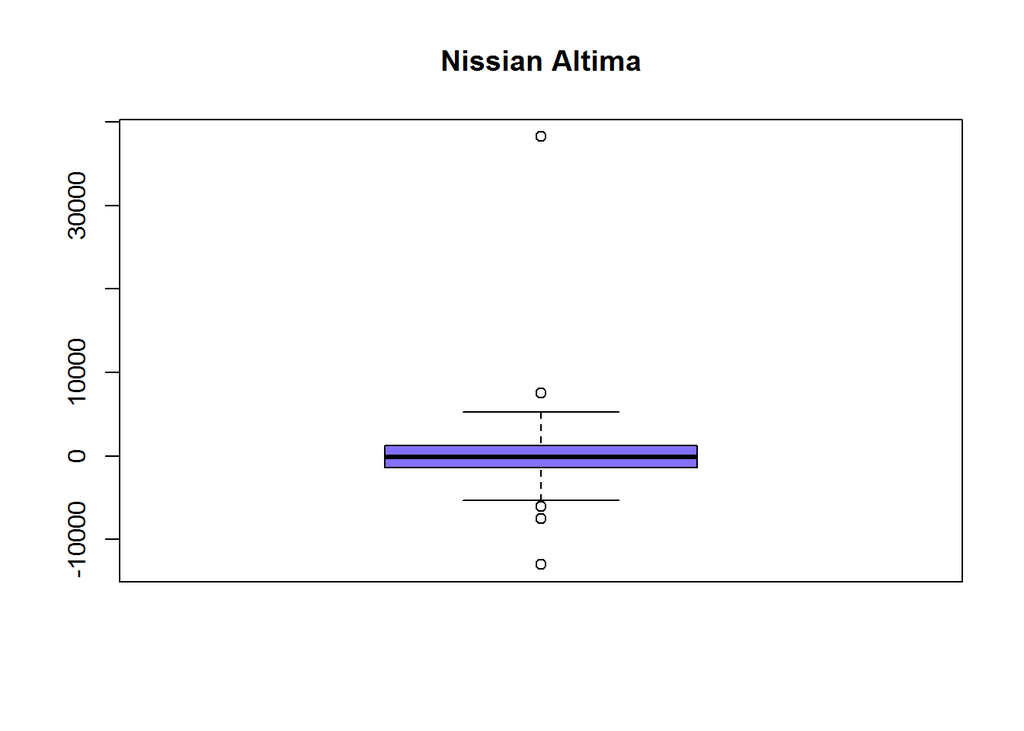

```r
#The boxplot shows that the distribution of the residuals is not symmetric and there are several outliers
boxplot(altimaModel$residuals,
        main = "Nissian Altima",
        col = "lightslateblue")
```

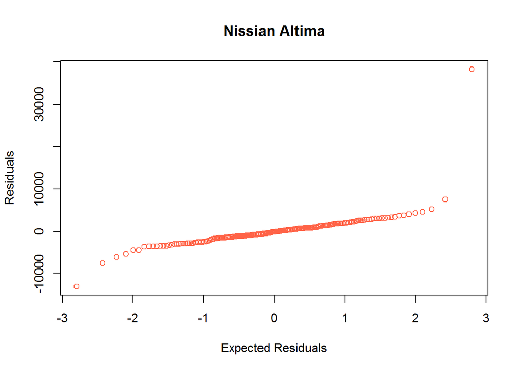

```r
#although the The normal probability plot of the residuals shows a strongly linear fit, there are noticable outliers
qqnorm(altimaModel$residuals,
       col = "tomato", main = "Nissian Altima",
       xlab = "Expected Residuals", ylab = "Residuals")
```

I used a linear model to suggest the appropriate price for Nissian Altima vehicle given its age, mileage, and condition.

I picked the age and odometer readings of the vehicle based on time (which passes linearly), so this meant a high age (older vehicle) would have a high odometer readings. I tried to pick the ages and odometer readings to be similar. I used my own judgement to decide what was considered “new”, “excellent”, etc for age and odometer readings.

Using a linear model assumes the data we have is linear and it does not appear to be approiate statistical model because the linear relationship between Y (price) and X (age, odometer, condition) have an R-squared of 58.31%, which is not significant enough to say that Y and X have a strong linear relationship. Although time passes linearly on Earth, for example a 2014 vehicle with 100k miles is newer than a 2000 vehicle with 5000 miles, this means over time as a vehicle gets older, then the vehicle will have a negative price. This does not make sense because no one would pay someone to take away their vehicle. Since a 2014 vehicle with 100k miles is newer than a 2000 vehicle with 5000 miles, this means that odometer readings are not linear. So a higher odometer reading does not mean an older vehicle.

Using a linear model is a poor representation of Nissian Altima’s price given it’s age, milage, and condition. I would not use this model if I were buying or selling a Nissian Altima.

```r
#fit the vehicle in a linear model. Price of Prius is regressed on age, odometer and condition
priusModel = lm(price ~ age_of_vehicle + odometer + updated_Condition, data = prius)
```

```r
#R^2 is 0.7318 (listed as mutiple R-squared)
summary(priusModel)
```

[output not shown]

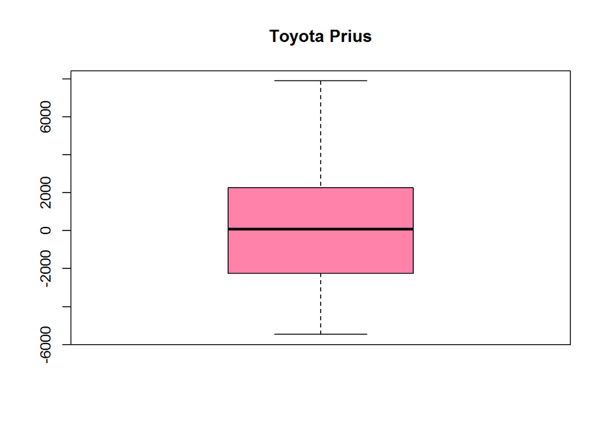

```r
predictPrius = data.frame(age_of_vehicle = c(1, 3, 5, 8, 11, 15, 25),
                              odometer = c(47, 99, 2600, 4785, 10935, 100000, 193634),
                              updated_Condition = c("new", "excellent", "good", "used", "fair", "salvage", "other"))
#I am not sure why, but the code below does not work
#pricePredictPrius = predict(priceModel, predictPrius)

#The boxplot shows that the distribution of the residuals is symmetric about 0 and there are no outliers.
boxplot(priusModel$residuals,
        main = "Toyota Prius",
        col = "palevioletred1")
```

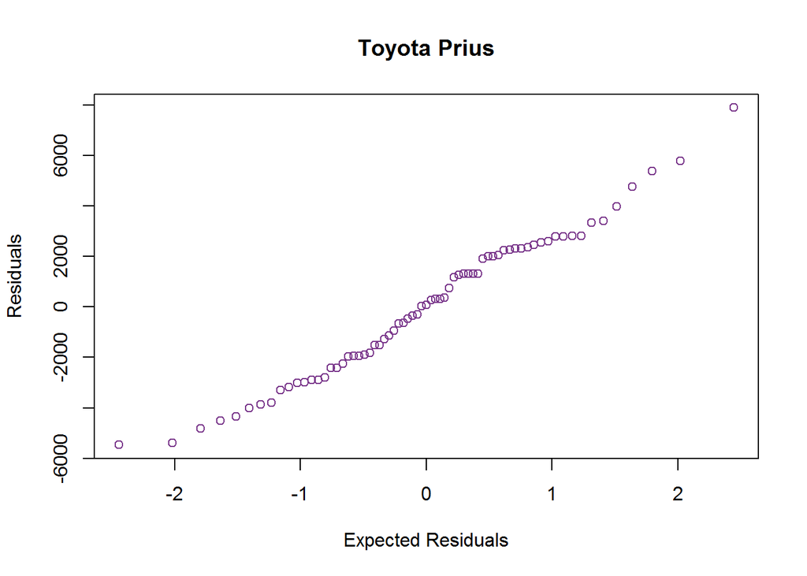

```r
#The normal probability plot of the residuals shows a strongly linear fit; however, there are a few outliers
qqnorm(priusModel$residuals,
       col = "mediumorchid4", main = "Toyota Prius",
       xlab = "Expected Residuals", ylab = "Residuals")
```

I used a linear model to suggest the appropriate price for Toyota Prius vehicle given its age, mileage, and condition.

I picked the age and odometer readings of the vehicle based on time (which passes linearly), so this meant a high age (older vehicle) would have a high odometer readings. I tried to pick the ages and odometer readings to be similar. I used my own judgement to decide what was considered “new”, “excellent”, etc for age and odometer readings.

Using a linear model assumes that the data we hve is linear and it appears a statistical model because R-squared is 73.18% which means there is a notiable linear relationship between Y (price) and X (age, odometer, condition).

However, Toyota Prius does not have any outliers (as shown in boxplot), so the residuals is symmetric about 0 and the resudals (age, odometer, condition) show a string linear fit.

Although it appears that using a linear model is a good representation of Toyota Prius, I would not use this model when buying a Toyota Prius because I have much less data points for Prius compared to Nissian. If I had more data to make my model with, I likely will have similar issues like I did with Nissian because odometer is not linear. Although time passes linearly on Earth, this means over time as a vehicle gets older, then the vehicle will have a negative price. This does not make sense because no one would pay someone to take away their vehicle. Since a 2014 vehicle with 100k miles is newer than a 2000 vehicle with 5000 miles, this means that odometer readings are not linear. So a higher odometer reading does not mean an older vehicle.